# Personal Information

##### PENN ID: zhxiong

# Load Libraries

```python
import pandas as pd
import time
import seaborn as sns
import altair as alt
from datetime import datetime, timedelta, date, time
from matplotlib import pyplot as plt
pd.options.mode.chained_assignment = None
```

# Read Datasets

### NYC DOB Complaints Datasets

```python
DOBCR = pd.read_csv("DOB_Complaints_Received.csv")
DOBCR = DOBCR.sort_values(["Date Entered"],ascending = False)
```

```python
DOBCatalog = pd.read_csv("complaint_category.csv")
DOBCatalog = DOBCatalog.rename(columns={'CODE':'Complaint Category'})
```

# Wrangle Datasets

#### Delete rows of 'Active' complaints

```python
delete = DOBCR.loc[(DOBCR['Status']=="ACTIVE")]
DOBCR = DOBCR.drop(delete.index)
```

#### Delete unwanted columns

```python
drop = pd.Series(['Status','House Number','House Street','BIN','Special District','Disposition Code','DOBRunDate','Inspection Date'])
DOBCR2 = DOBCR.drop(drop, axis=1)
```

#### Merge 'Complaint Category' and 'Complaint Category Description'

```python
DOBCR3 = DOBCR2.merge(DOBCatalog,on=['Complaint Category'], how='left')
```

#### Time Arrangement

Transform into datatime format

Select specific range

Extract 'month'

Calculate the Reaction Time

```python
DOBCR3['Date Entered'] = pd.to_datetime(DOBCR3['Date Entered'])
DOBCR3['Disposition Date'] = pd.to_datetime(DOBCR3['Disposition Date'])

mask = (DOBCR3['Date Entered']> '2020-01-01')
T_DOBCR = DOBCR3.loc[mask]
T_DOBCR['counter'] = float(1)
T_DOBCR = T_DOBCR.sort_values(['Disposition Date'],ascending = True)

T_DOBCR ['Month_DEntered'] = T_DOBCR ['Date Entered'].dt.strftime("%m")
T_DOBCR ['Y_DEntered'] = T_DOBCR ['Date Entered'].dt.strftime("%Y")

T_DOBCR['ReactionTime'] = (T_DOBCR['Disposition Date'] - T_DOBCR['Date Entered']).dt.days
T_DOBCR['ReactionTime'] = T_DOBCR['ReactionTime'] + int(1)
```

#### Allocate borough

```python
T_DOBCR.loc[T_DOBCR['Complaint Number']<=5999999, 'borough'] = 'Staten Island'
T_DOBCR.loc[T_DOBCR['Complaint Number']<=4999999, 'borough'] = 'Queen'
T_DOBCR.loc[T_DOBCR['Complaint Number']<=3999999, 'borough'] = 'Brooklyn'
T_DOBCR.loc[T_DOBCR['Complaint Number']<=2999999, 'borough'] = 'Bronx'
T_DOBCR.loc[T_DOBCR['Complaint Number']<=1999999, 'borough'] = 'Manhattan'
```

# Matplotlib

### Scatter Plot - Relationship between 'Different Complaint Type' & 'Occurrence Frequency' in Different Region

##### The reason I chose Matplotlib to plot is that subplot of matplotlib is considerably convenient to take a look at all regions at the same time with high degree of customization.

```python
DDsumDOB = T_DOBCR.groupby(["COMPLAINT CATEGORY DESCRIPTION","Y_DEntered",'borough'],as_index=False).sum('counter').sort_values(["counter"],ascending = False)
DDsumDOB2 = T_DOBCR.groupby(["COMPLAINT CATEGORY DESCRIPTION",'borough'],as_index=False).sum('counter').sort_values(["counter"],ascending = False)
DDsumDOB = DDsumDOB.drop('ReactionTime',axis=1)
DDsumDOB2 = DDsumDOB2.drop('ReactionTime',axis=1)

DDsumDOB = DDsumDOB.merge(DOBCatalog,on = ['COMPLAINT CATEGORY DESCRIPTION'], how='left')
DDsumDOB2 = DDsumDOB2.merge(DOBCatalog,on = ['COMPLAINT CATEGORY DESCRIPTION'], how='left')

Bronx = DDsumDOB.loc[DDsumDOB.borough=='Bronx']
Brooklyn = DDsumDOB.loc[DDsumDOB.borough=='Brooklyn']
Manhattan = DDsumDOB.loc[DDsumDOB.borough=='Manhattan']
Queen = DDsumDOB.loc[DDsumDOB.borough=='Queen']
StatenIsland = DDsumDOB.loc[DDsumDOB.borough=='Staten Island']

Bronx2020 = Bronx.loc[Bronx.Y_DEntered=='2020']
Bronx2020 = Bronx2020.sort_values(["Complaint Category"],ascending = False)
Bronx2021 = DDsumDOB2.loc[DDsumDOB2.borough=='Bronx']
Bronx2021 = Bronx2021.sort_values(["Complaint Category"],ascending = False)

Brooklyn2020 = Brooklyn.loc[Brooklyn.Y_DEntered=='2020']
Brooklyn2021 = DDsumDOB2.loc[DDsumDOB2.borough=='Brooklyn']
Brooklyn2020 = Brooklyn2020.sort_values(["Complaint Category"],ascending = False)
Brooklyn2021 = Brooklyn2021.sort_values(["Complaint Category"],ascending = False)

Manhattan2020 = Manhattan.loc[Manhattan.Y_DEntered=='2020']
Manhattan2021 = DDsumDOB2.loc[DDsumDOB2.borough=='Manhattan']
Manhattan2020 = Manhattan2020.sort_values(["Complaint Category"],ascending = False)
Manhattan2021 = Manhattan2021.sort_values(["Complaint Category"],ascending = False)

Queen2020 = Queen.loc[Queen.Y_DEntered=='2020']
Queen2021 = DDsumDOB2.loc[DDsumDOB2.borough=='Queen']
Queen2020 = Queen2020.sort_values(["Complaint Category"],ascending = False)
Queen2021 = Queen2021.sort_values(["Complaint Category"],ascending = False)

StatenIsland2020 = StatenIsland.loc[StatenIsland.Y_DEntered=='2020']
StatenIsland2021 = DDsumDOB2.loc[DDsumDOB2.borough=='StatenIsland']
Queen2020 = Queen2020.sort_values(["Complaint Category"],ascending = False)
Queen2021 = Queen2021.sort_values(["Complaint Category"],ascending = False)
```

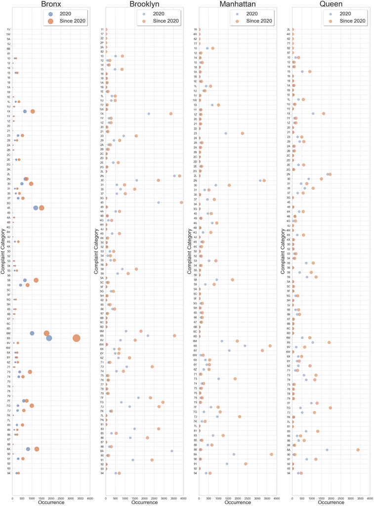

```python
fig, ax = plt.subplots(figsize=(50, 70))

plt.subplot(141)
plt.scatter( 'counter','Complaint Category', data=Bronx2020, s='counter',marker='o', alpha=0.6)
plt.scatter( 'counter','Complaint Category', data=Bronx2021, s='counter',marker='o', alpha=0.8)
plt.title("Bronx",fontsize=60)
plt.xlabel("Occurrence",fontsize=40)
plt.ylabel("Complaint Category",fontsize=40)
plt.grid(color='lightgrey', linestyle='dashed')
plt.legend(('2020', 'Since 2020'),
           loc='upper right', shadow=True,fontsize=40)
plt.xlim(-1, 4000)


plt.subplot(142)
plt.scatter( 'counter','Complaint Category', data=Brooklyn2020, s=300,marker='o', alpha=0.4)
plt.scatter( 'counter','Complaint Category',data=Brooklyn2021, s=500,marker='o', alpha=0.6)
plt.title("Brooklyn",fontsize=60)
plt.xlabel("Occurrence",fontsize=40)
plt.ylabel("Complaint Category",fontsize=40)
plt.grid(color='lightgrey', linestyle='dashed')
plt.legend(('2020', 'Since 2020'),
           loc='upper right', shadow=True,fontsize=40)
plt.xlim(-1, 4000)


plt.subplot(143)
plt.scatter( 'counter','Complaint Category', data=Manhattan2020,s=300, marker='o', alpha=0.4)
plt.scatter('counter','Complaint Category', data=Manhattan2021, s=500,marker='o', alpha=0.6)
plt.title("Manhattan",fontsize=60)
plt.xlabel("Occurrence",fontsize=40)
plt.ylabel("Complaint Category",fontsize=40)
plt.grid(color='lightgrey', linestyle='dashed')
plt.legend(('2020', 'Since 2020'),
           loc='upper right', shadow=True,fontsize=40)
plt.xlim(-1, 4000)


plt.subplot(144)
plt.scatter( 'counter','Complaint Category',data=Queen2020, s=300,marker='o', alpha=0.4)
plt.scatter('counter','Complaint Category', data=Queen2021, s=500,marker='o', alpha=0.6)
plt.title("Queen",fontsize=60)
plt.xlabel("Occurrence",fontsize=40)
plt.ylabel("Complaint Category",fontsize=40)
plt.grid(color='lightgrey', linestyle='dashed')
plt.legend(('2020', 'Since 2020'),
           loc='upper right', shadow=True,fontsize=40)
plt.xlim(-1, 4000)


plt.show()
```

# Seaborn

### Bar Chart - Relationship between 'Complaint Type' & 'Occurrence'

```python
T_DOBCR['Complaint Number']=str(T_DOBCR['Complaint Number'])
sumDOB = T_DOBCR.groupby(["COMPLAINT CATEGORY DESCRIPTION","Y_DEntered"],as_index=False).sum('counter').sort_values(["counter"],ascending = False)
sumDOB_drop = sumDOB.loc[(sumDOB['counter']< 100)]
sumDOB_dd = sumDOB.drop(sumDOB_drop.index)
sumDOB_dd = sumDOB_dd.drop('ReactionTime',axis=1)
sumDOB_dd = sumDOB_dd.pivot(index='COMPLAINT CATEGORY DESCRIPTION',columns='Y_DEntered',values='counter')
sumDOB_dd.reset_index(drop=False, inplace=True)
sumDOB_dd = sumDOB_dd.sort_values(["2020"],ascending = False)
sumDOB_dd['2020'].fillna(0, inplace=True)
sumDOB_dd['2021'].fillna(0, inplace=True)
sumDOB_dd['total'] = (sumDOB_dd['2020'] + sumDOB_dd['2021'])
```

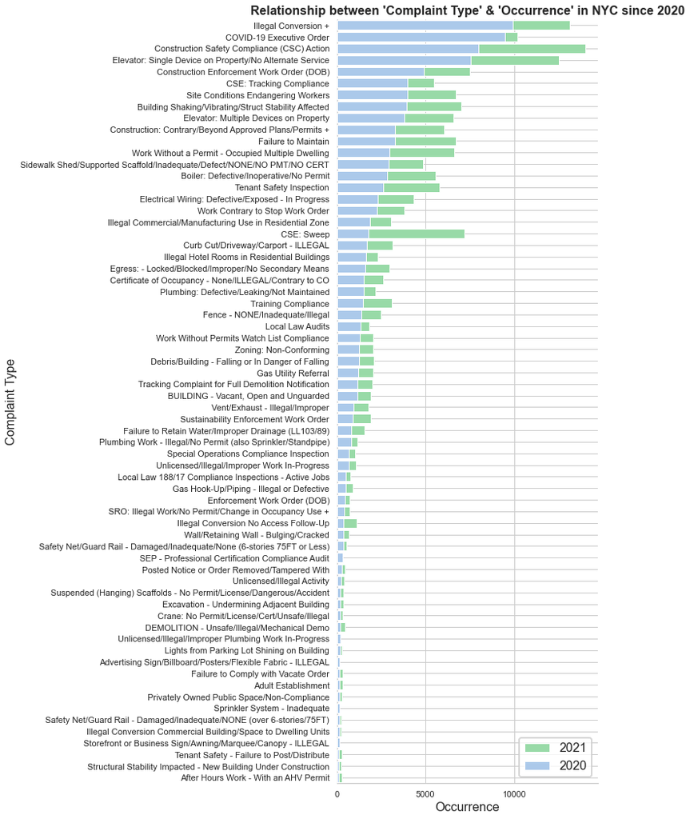

```python
sns.set_theme(style="whitegrid")
fig, ax = plt.subplots(figsize=(6, 18))
sns.set_color_codes("pastel")

sns.barplot(
    x="total",
    y="COMPLAINT CATEGORY DESCRIPTION",
    data=sumDOB_dd,
    label = "2021",
    color="g",
    ax=ax,
    zorder=999,
)

sns.barplot(
    x="2020",
    y="COMPLAINT CATEGORY DESCRIPTION",
    data=sumDOB_dd,
    label = "2020",
    color="b",
    ax=ax,
    zorder=999,
)

sns.set_context(
    "poster",
    font_scale=1,
    rc={"lines.linewidth":2.5}
               )
ax.set_xlabel("Occurrence",fontsize=16)
ax.set_ylabel("Complaint Type",fontsize=16)
ax.grid(True, axis="y")
ax.spines["top"].set_visible(False)
ax.spines["right"].set_visible(False)
ax.set_title(
    "Relationship between 'Complaint Type' & 'Occurrence' in NYC since 2020", weight="bold", fontsize=16
)

ax.legend(ncol=1, loc="lower right", frameon=True,prop={'size':16})
```

### Bar Chart - Relationship between 'Borough' & 'Occurrence'

```python
DistDOB = T_DOBCR.groupby(["borough","Y_DEntered"],as_index=False).sum('counter').sort_values(["counter"],ascending = False)
DistDOB_drop = DistDOB.loc[(DistDOB['counter']< 100)]
DistDOB_dd = DistDOB.drop(DistDOB_drop.index)
DistDOB_dd = DistDOB_dd.drop('ReactionTime',axis=1)
DistDOB_dd = DistDOB_dd.pivot(index='borough',columns='Y_DEntered',values='counter')
DistDOB_dd.reset_index(drop=False, inplace=True)
DistDOB_dd = DistDOB_dd.sort_values(["2020"],ascending = False)
DistDOB_dd['2020'].fillna(0, inplace=True)
DistDOB_dd['2021'].fillna(0, inplace=True)
DistDOB_dd['total'] = (DistDOB_dd['2020'] + DistDOB_dd['2021'])
```

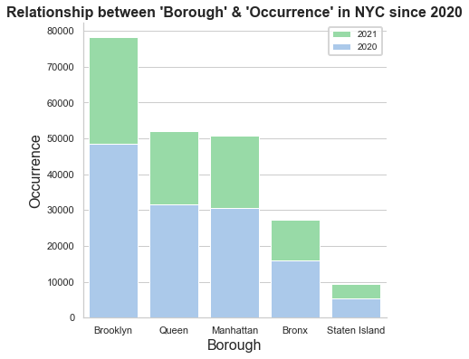

```python
sns.set_theme(style="whitegrid")
fig, ax = plt.subplots(figsize=(6, 6))
sns.set_color_codes("pastel")

sns.barplot(
    x="borough",
    y="total",
    data=DistDOB_dd,
    label = "2021",
    color="g",
    ax=ax,
    zorder=999,
)

sns.barplot(
    x="borough",
    y="2020",
    data=DistDOB_dd,
    label = "2020",
    color="b",
    ax=ax,
    zorder=999,
)

sns.set_context(
    "poster",
    font_scale=0.5,
    rc={"lines.linewidth":2.5}
               )
ax.set_xlabel("Borough",fontsize=16)
ax.set_ylabel("Occurrence",fontsize=16)
ax.grid(True, axis="y")
ax.spines["top"].set_visible(False)
ax.spines["right"].set_visible(False)
ax.set_title(
    "Relationship between 'Borough' & 'Occurrence' in NYC since 2020", weight="bold", fontsize=16
)

ax.legend(ncol=1, loc="upper right", frameon=True,prop={'size':10})
```

```python
RTimegroup_DOB = T_DOBCR.groupby(["ReactionTime"],as_index=False).sum('counter').sort_values(["ReactionTime"],ascending = False)
RTimegroup_DOB = RTimegroup_DOB.loc[(RTimegroup_DOB['counter']> 1000)]
```

```
No handles with labels found to put in legend.
```

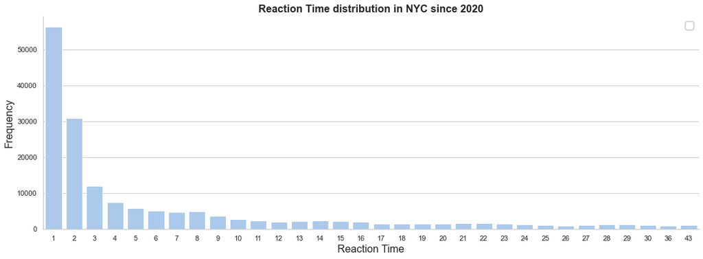

```python
sns.set_theme(style="whitegrid")
fig, ax = plt.subplots(figsize=(18, 6))
sns.set_color_codes("pastel")

sns.barplot(
    x="ReactionTime",
    y="counter",
    data=RTimegroup_DOB,
    color="b",
    ax=ax,
    zorder=999,
)

sns.set_context(
    "poster",
    font_scale=1,
    rc={"lines.linewidth":1}
               )
ax.set_xlabel("Reaction Time",fontsize=16)
ax.set_ylabel("Frequency",fontsize=16)
ax.grid(True, axis="y")
ax.spines["top"].set_visible(False)
ax.spines["right"].set_visible(False)
ax.set_title(
    "Reaction Time distribution in NYC since 2020", weight="bold", fontsize=16
)

ax.legend(ncol=1, loc="upper right", frameon=True,prop={'size':16})
```

# Altair

### Scatter Chart - Relationship between Monthly Distribution and Reaction Time

```python
month_T_DOBCR = T_DOBCR.groupby(['Month_DEntered','ReactionTime'],as_index=False).sum('counter')
month_T_DOBCR = month_T_DOBCR.loc[month_T_DOBCR['counter']>100]
```

```python
chart = alt.Chart(month_T_DOBCR).mark_circle(
    opacity=0.6,
    stroke='black',
    strokeWidth=1
).encode(
    alt.X('Month_DEntered:O',axis=alt.Axis(labelAngle=0)),
    alt.Y('ReactionTime:N',axis=alt.Axis(values=[1,11,21,31,41,51,61])),
    alt.Size('counter:Q',
        scale=alt.Scale(range=[0, 500]),
        legend=alt.Legend(title='Total Occurrence')
    ),
    tooltip=["Month_DEntered","ReactionTime","counter"],
    color = alt.value("#FF8542")
).properties(
    width=600,
    height=400,
    title = 'Monthly Distribution of Reaction Time'
)
chart.encoding.x.title = 'Month'
chart.encoding.y.title = 'Reaction Time / day'
chart
```

[interactive chart not shown]

##### This diagram was generated for exploration. From this plot, we can know that there is not an obvious tendency of reaction time between different months, which was my bias when trying to do this plot.

### Scatter Chart - Time Distribution of Different Complaint Type in NYC since 2020

```python
dt_T_DOBCR = T_DOBCR.groupby(['Date Entered','COMPLAINT CATEGORY DESCRIPTION'],as_index=False).sum()
dt_T_DOBCR = dt_T_DOBCR.drop('ReactionTime',axis=1)
dt_T_DOBCR = dt_T_DOBCR.sort_values('counter')
CODE_dt_T_DOBCR = dt_T_DOBCR.merge(DOBCatalog,on = ['COMPLAINT CATEGORY DESCRIPTION'], how='left')
```

```python
alt.data_transformers.disable_max_rows()

chart2 = alt.Chart(CODE_dt_T_DOBCR).mark_circle(
    opacity=0.4,
    stroke='darkorange',
    strokeWidth=1
).encode(
    alt.X('Date Entered',axis=alt.Axis(labelAngle=0)),
    alt.Y('Complaint Category:O'),
    alt.Size('counter:Q',
        scale=alt.Scale(range=[0, 1000]),
        legend=alt.Legend(title='Total Occurrence')
    ),
    tooltip=["Date Entered","Complaint Category","COMPLAINT CATEGORY DESCRIPTION","counter"],
    color = alt.value("#F79D46")
).properties(
    width=1500,
    height=1200,
    title = 'Time Distribution of Different Complaint Type in NYC since 2020'
).configure_axis(
    labelFontSize=8,
    titleFontSize=10
).interactive()
chart2.encoding.x.title = 'Date Entered'
chart2.encoding.y.title = 'Complaint Category'

chart2
```

[interactive chart not shown]

```python
chart2.to_dict()
```

[output not shown]

##### Conclusion

###### This huge plot was made to take a detailed look at the time distribution of different complaint type since 2020. Though the information may not be so abundat as it looks, but it still provides some information. Most of the complaints don't have a specific burst period but are evenly distributed during the year. However, '7G' complaint has a surge from 06/2020 - 07/2020. '2N' had a realtively densed distribution from 04/2020 - 06/2020. Also the complaints decreased between 04/2020 - 07/2020, which might be the cause of COVID-19.

### Heat map - County Distribution of Different Complaint Type in NYC since 2020

```python
B_T_DOBCR = T_DOBCR.groupby(['borough','COMPLAINT CATEGORY DESCRIPTION'],as_index=False).sum()
B_T_DOBCR = B_T_DOBCR.merge(DOBCatalog,on = ['COMPLAINT CATEGORY DESCRIPTION'], how='left')
```

```python
alt.data_transformers.enable('json')
alt.data_transformers.disable_max_rows()
colormap = alt.Scale(
    domain=[0, 100, 200, 300, 1000, 5000],
    range=[
        "#F0F8FF",
        "cornflowerblue",
        "mediumseagreen",
        "#FFEE00",
        "darkorange",
        "firebrick",
    ],
    type="sqrt",
)

chart = alt.Chart(B_T_DOBCR).mark_rect().encode(
       y=alt.Y("borough:O", axis=alt.Axis(title=None, ticks=False), scale=alt.Scale(zero=False)),
       x=alt.X("Complaint Category", axis=alt.Axis(title=None, ticks=False,labelAngle=0), scale=alt.Scale(zero=False)),
       color=alt.Color("counter", sort="ascending", scale=colormap),
       tooltip=["borough", "COMPLAINT CATEGORY DESCRIPTION", "counter"],
   ).properties(
    width=1800,
    height=100,
    title = 'County Distribution of Different Complaint Type in NYC since 2020'
).configure_axis(
    labelFontSize=8,
    titleFontSize=10
)
chart.encoding.x.title = 'Date Entered'
chart.encoding.y.title = 'Complaint Category'
chart
```

[interactive chart not shown]

##### Conclusion

###### Corresponding to the above plots, Brooklyn and Queen have relatively high numbers of DOB complaints. Besides, the pattern of complaint distribution does not have a county distribution tendency. The frequent complaints types, which are '03' - '05', '2N' - '45', '6M' - '74' and '83' - '91', remain nearly the same in these five counties.

### Brush Selection - Relationship between Reaction Time and Occurrence Frequency with respect to different complaint types and counties.

```python
counter_pyramid_T_DOBCR3 = T_DOBCR.groupby(['COMPLAINT CATEGORY DESCRIPTION','borough'],as_index=False).sum('counter')
counter_pyramid_T_DOBCR3 = counter_pyramid_T_DOBCR3.drop('ReactionTime',axis=1)
mean_pyramid_T_DOBCR3 = T_DOBCR.groupby(['COMPLAINT CATEGORY DESCRIPTION','borough'],as_index=False).mean('ReactionTime')
mean_pyramid_T_DOBCR3 = mean_pyramid_T_DOBCR3.drop('counter',axis=1)
c_pyramid_T_DOBCR3 = counter_pyramid_T_DOBCR3.merge(mean_pyramid_T_DOBCR3,on=['COMPLAINT CATEGORY DESCRIPTION','borough'], how='left')
c_pyramid_T_DOBCR3 = c_pyramid_T_DOBCR3.merge(DOBCatalog,on = ['COMPLAINT CATEGORY DESCRIPTION'], how='left')
c_pyramid_T_DOBCR3['ReactionTime'] = c_pyramid_T_DOBCR3['ReactionTime'].round(decimals = 1)
```

```python
brush = alt.selection(type='interval')
left = (
    alt.Chart(c_pyramid_T_DOBCR3)
    .mark_point(size=80)
    .encode(
        x=alt.X('Complaint Category:O',axis=alt.Axis( labels=False,ticks=False)),
        y=alt.Y('ReactionTime:O',axis=alt.Axis(),sort='ascending'),
        tooltip=["ReactionTime", "COMPLAINT CATEGORY DESCRIPTION", "counter"],
        color=alt.condition(brush,"borough:N" ,alt.value("lightgray"))
    ).properties(
        selection=brush,
        width=1800, height=300)
)

middle = (
    alt.Chart(c_pyramid_T_DOBCR3)
    .mark_text()
    .encode(
        x=alt.X('Complaint Category:O',axis=None),
        text=alt.Text('Complaint Category:O'),
        color=alt.condition(brush,":O" ,alt.value("lightgray"))
).properties(width=1800, height=0)
)

right = (
    alt.Chart(c_pyramid_T_DOBCR3)
    .mark_point(size=80)
    .encode(
        x=alt.X('Complaint Category:O',axis=alt.Axis(ticks=False,labels=False)),
        y=alt.Y('counter:O',axis=alt.Axis(), sort='descending'),
        tooltip=["ReactionTime", "COMPLAINT CATEGORY DESCRIPTION",'Complaint Category:O', "counter"],
        color=alt.condition(brush,"borough:N" ,alt.value("lightgray"))
    ).properties(
        selection=brush,
        width=1800, height=300)
)
right.encoding.y.title = 'Total Occurrence'
left.encoding.y.title = 'Average Reaction Time'
alt.vconcat(right,middle,left).configure_axis(
    labelFontSize=10,
    titleFontSize=10)
```

[interactive chart not shown]

##### Conclusion

###### Even though there is not an intuitive and overall conclusion at the first glimpse, this diagram gives an opportunity to detailedly look at the distribution pattern. For example, to the '03' complaint type, we can know that even though there is great variance in the total occurrence of five counties, the average reaction times of five counties are the same, concentrating at 5-10 days. And for '1X' complaint type, we can nearly see a reversed relationship between total occurrence and average reaction time. It seems that the more it occurs, the longer the reaction time will be, which requires us to take a further look to draw the conclusion.

### Dashboard

```python
brush = alt.selection(type='interval')
up = (
    alt.Chart(c_pyramid_T_DOBCR3)
    .mark_point(size=40)
    .encode(
        x=alt.X('Complaint Category:O',axis=alt.Axis(labelAngle=0),scale=alt.Scale(zero=False)),
        y=alt.Y('ReactionTime:O',scale=alt.Scale(zero=False),sort='descending'),
        tooltip=["ReactionTime", "COMPLAINT CATEGORY DESCRIPTION", "counter"],
        color=alt.condition(brush,"borough:N" ,alt.value("lightgray"))
    ).properties(
        selection=brush,
        width=800, height=300)
)

down = (
    alt.Chart(c_pyramid_T_DOBCR3)
    .mark_bar()
    .encode(
        x='count(counter):O',
        y='borough:N',
        color='borough:N',
    ).transform_filter(
        brush.ref()
    ).properties(width=800)
)

chart = alt.vconcat(up,down)
chart
```

[interactive chart not shown]

##### Conclusion

###### This dashboard tells us that '3A' - '4A' get large reaction time for five counties, which are longer than 55 days. In the fastest reaction time selction, Staten Island gets a largest number of occurrcence. In the longest reaction time selction, Queen county gets a largest number of occurrcence. In the mild reaction time selction, Brooklyn gets a largest number of occurrcence.